# Projekt Zaliczeniowy - Wizualizacja danych

Hanna Sopala

Iga Bochniak

2026-04-17

```r
pacman::p_load(
  RColorBrewer,
  ggplot2,
  stringr,
  lubridate # do 4.
  )
```

# TO DO

**Nanieść na mapę wybrane statystyki dotyczące przejazdów w punktach pomiarowych**

**Przedstawić zależności między zmiennymi opisującymi warunki pogodowe**

**Dodatkowo punktowane będzie wykonanie aplikacji w Shiny, w ramach której można wykonać wszystkie lub część poleceń.**

**Sprawdzić Hani część, czy wszystko git, można coś dorobić zwłaszcza w podpunktach “dla wybranych blablabla”**

**Nwm czy trzeba, ale jak chcesz to mozesz cos dopisac typu zdanie jakiegos wniosku czy co**

# Wstęp

Celem niniejszego opracowania jest analiza oraz wizualizacja danych dotyczących ruchu rowerowego w Gdańsku w oparciu o system automatycznych punktów pomiarowych. Projekt skupia się na zbadaniu dynamiki przejazdów, identyfikacji wzorców czasowych oraz określeniu wpływu warunków atmosferycznych na aktywność rowerzystów.

W zbiorach danych znajdują się informacje o dziennych liczbach przejazdów rowerowych w wybranych punktach, informacje o warunkach pogodowych w danym dniu oraz współrzędne geograficzne punktów pomiarowych.

| Zmienna | Opis |
| --- | --- |
| `Stacja` | Punkt pomiarowy |
| `Licznik` | Liczba przejazdów |
| `Data` | Data [rok-miesiąc-dzień] |
| `Zachmurzenie` | Średnie dobowe zachmurzenie ogólne [oktanty] |
| `Wiatr` | Średnia dobowa prędkość wiatru [m/s] |
| `Temperatura` | Średnia dobowa temperatura [C] |
| `Ciśnienie_woda` | Średnie dobowe ciśnienie pary wodnej [hPa] |
| `Wilgotność` | Średnia dobowa wilgotność względna [%] |
| `Ciśnienie_stacja` | Średnie dobowe ciśnienie na poziomie stacji [hPa] |
| `Ciśnienie_morze` | Średnie dobowe ciśnienie na poziomie morza [hPa] |
| `Opady_dzień` | Suma opadu dzień [mm] |
| `Opady_noc` | Suma opadu noc [mm] |
| `Geometry` | Współrzędne geograficzne punktu pomiaru |

Zbiory są kompletne i nie zawierają braków danych.

```r
sum(is.na(przejazdy))
```

```
## [1] 0
```

```r
sum(is.na(punkty))
```

```
## [1] 0
```

```r
paleta_kolorow <- brewer.pal(9, "RdPu")
```

# Wizualizacje

## Rozkład liczby dni pomiarowych w poszczególnych punktach

```r
dni_per_stacja <- sort(table(przejazdy$Stacja), decreasing = FALSE)
```

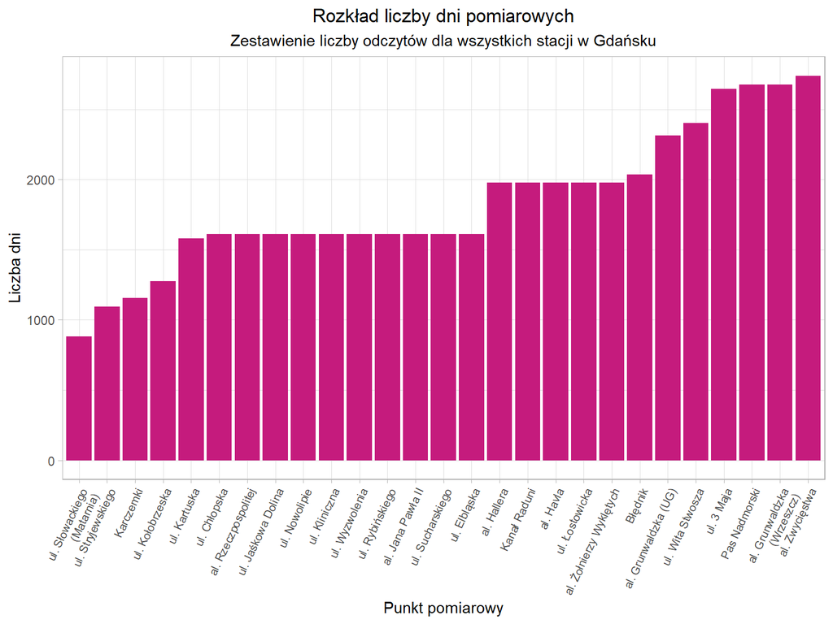

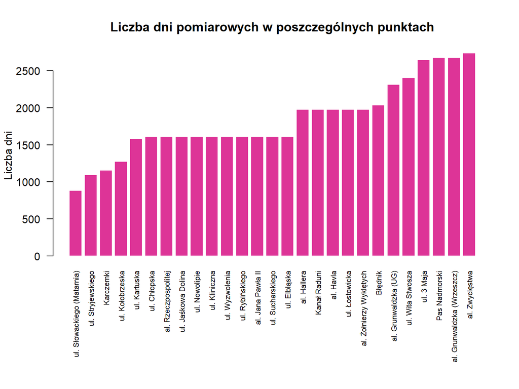

## Rozkład liczby przejazdów dla wybranego punktu

```r
stacja_wybrana <- "ul. Chłopska"
dane_stacja <- przejazdy[przejazdy$Stacja == stacja_wybrana, ]
```

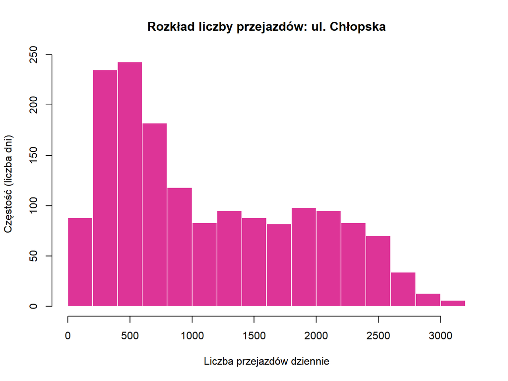

```r
par(mar = c(5, 4, 4, 2) + 0.1)

hist(dane_stacja$Licznik,
     breaks = 20,
     main = paste("Rozkład liczby przejazdów:", stacja_wybrana),
     xlab = "Liczba przejazdów dziennie",
     ylab = "Częstość (liczba dni)",
     col = paleta_kolorow[6],
     border = "white")
```

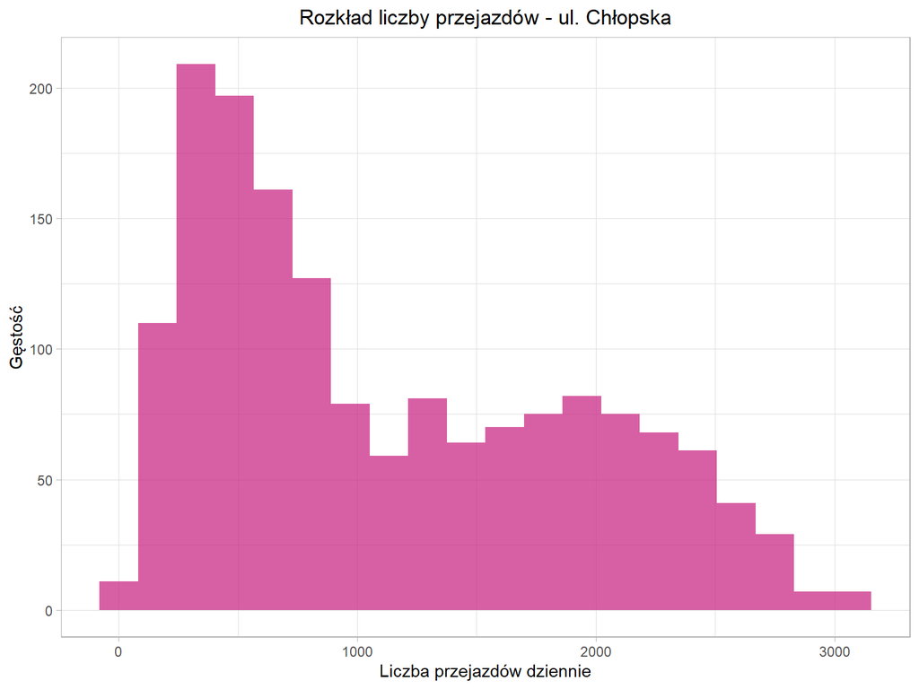

```r
ggplot(dane_stacja, aes(x = Licznik)) +
  geom_histogram(bins = 20,
                 fill = "#C51B7D",
                 alpha = 0.7) +
  labs(title = paste("Rozkład liczby przejazdów -", stacja_wybrana),
       x = "Liczba przejazdów dziennie",
       y = "Gęstość") +
  theme_light() +
  theme(plot.title = element_text(hjust = 0.5),
        plot.subtitle = element_text(hjust = 0.5))
```

## Porównanie punktów pod względem natężenia / rozkładu przejazdów

```r
stacje_order <- aggregate(Licznik ~ Stacja, data = przejazdy, median)
stacje_order <- stacje_order$Stacja[order(stacje_order$Licznik)]

przejazdy$Stacja_f <- factor(przejazdy$Stacja, levels = stacje_order)
```

Stacje posortowane według mediany dziennej liczby przejazdów.

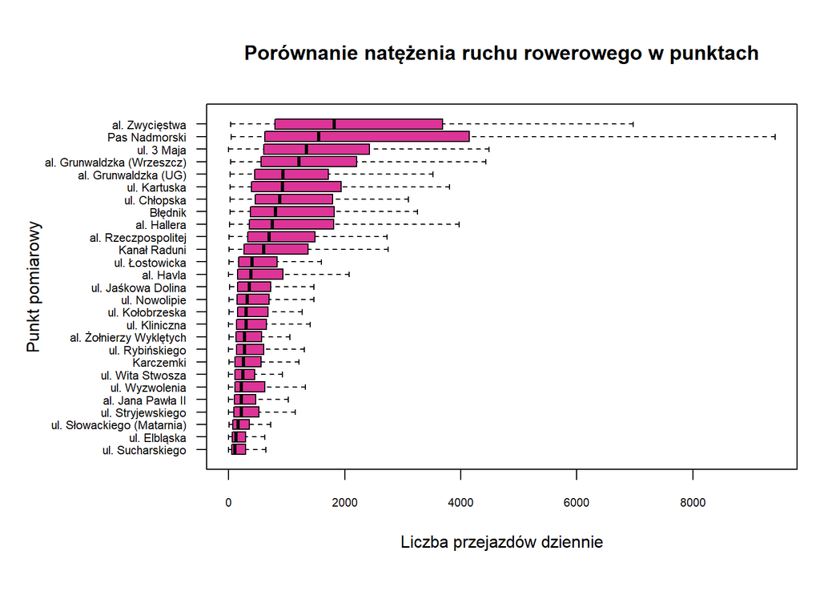

```r
par(mar = c(7, 10, 5, 1) + 0.1)

boxplot(Licznik ~ Stacja_f,
        data = przejazdy,
        horizontal = TRUE,
        las = 1,
        col = paleta_kolorow[6],
        outline = FALSE,
        main = "Porównanie natężenia ruchu rowerowego w punktach",
        xlab = "Liczba przejazdów dziennie",
        ylab = "", # ciagle nam nachodzilo na wartosci na osi Y
        cex.axis = 0.7)

title(ylab = "Punkt pomiarowy", line = 8, cex.lab = 1) # sposob obejscia problemu
```

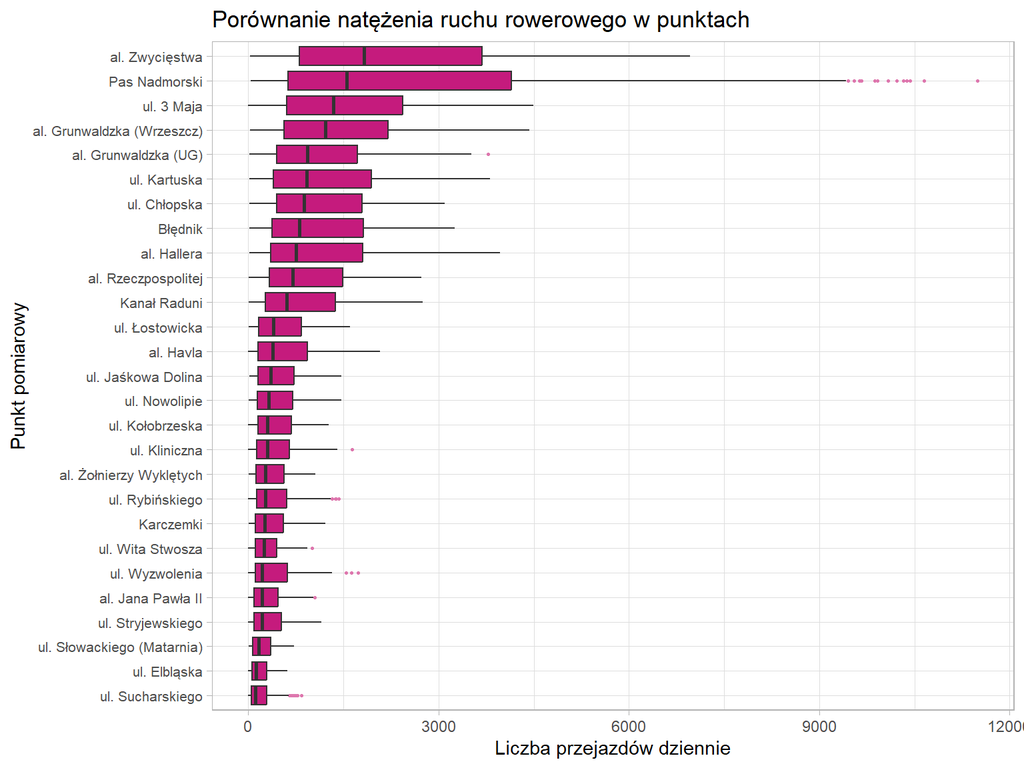

```r
ggplot(przejazdy, aes(x = Stacja_f, y = Licznik)) +
  geom_boxplot(fill = "#C51B7D",
               outlier.color = "#DE77AE",
               outlier.size = 0.5) +
  coord_flip() +
  labs(title = "Porównanie natężenia ruchu rowerowego w punktach",
       x = "Punkt pomiarowy",
       y = "Liczba przejazdów dziennie") +
  theme_light() +
  theme(axis.text.y = element_text(size = 8))
```

## Natężenie / rozkład przejazdów dla wybranej stacji w zależności od miesiąca / dnia tygodnia / dni powszednich/weekendowych

```r
przejazdy$Miesiac <- month(przejazdy$Data, label = TRUE, abbr = FALSE)
przejazdy$DzienTyg <- wday(przejazdy$Data, label = TRUE, abbr = FALSE, week_start = 1)
przejazdy$TypDnia <- ifelse(przejazdy$DzienTyg %in% c("sobota", "niedziela"), "Weekend", "Dzień powszedni")

dane_stacja <- przejazdy[przejazdy$Stacja == "ul. Chłopska", ]
```

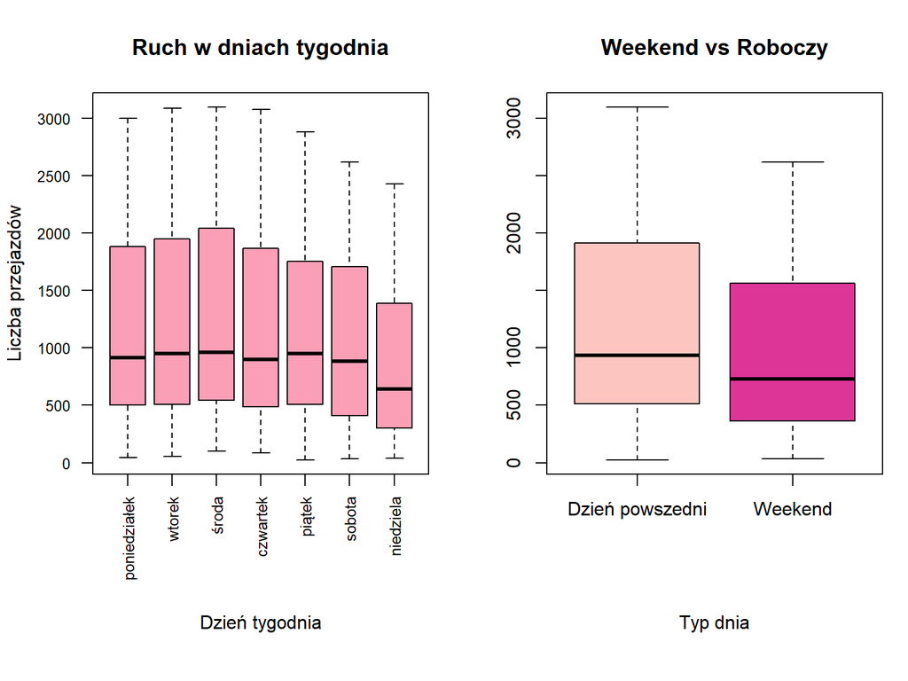

```r
par(mfrow = c(1, 2), mar = c(9, 4, 4, 1) + 0.1)

boxplot(Licznik ~ DzienTyg, data = dane_stacja,
        main = "Ruch w dniach tygodnia",
        col = paleta_kolorow[4], las = 2, cex.axis = 0.8,
        ylab = "Liczba przejazdów", xlab = "") # musiałyśmy usunąć tutaj tytuł osi x bo nachodzi na etykiety

title(xlab = "Dzień tygodnia", line = 6)

boxplot(Licznik ~ TypDnia, data = dane_stacja,
        main = "Weekend vs Roboczy",
        col = c(paleta_kolorow[3], paleta_kolorow[6]),
        ylab = "", xlab = "") # tu nie nachodzi ale brzydko było nierówno z tym pierwszym

title(xlab = "Typ dnia", line = 6)
```

```r
par(mfrow = c(1,1))
```

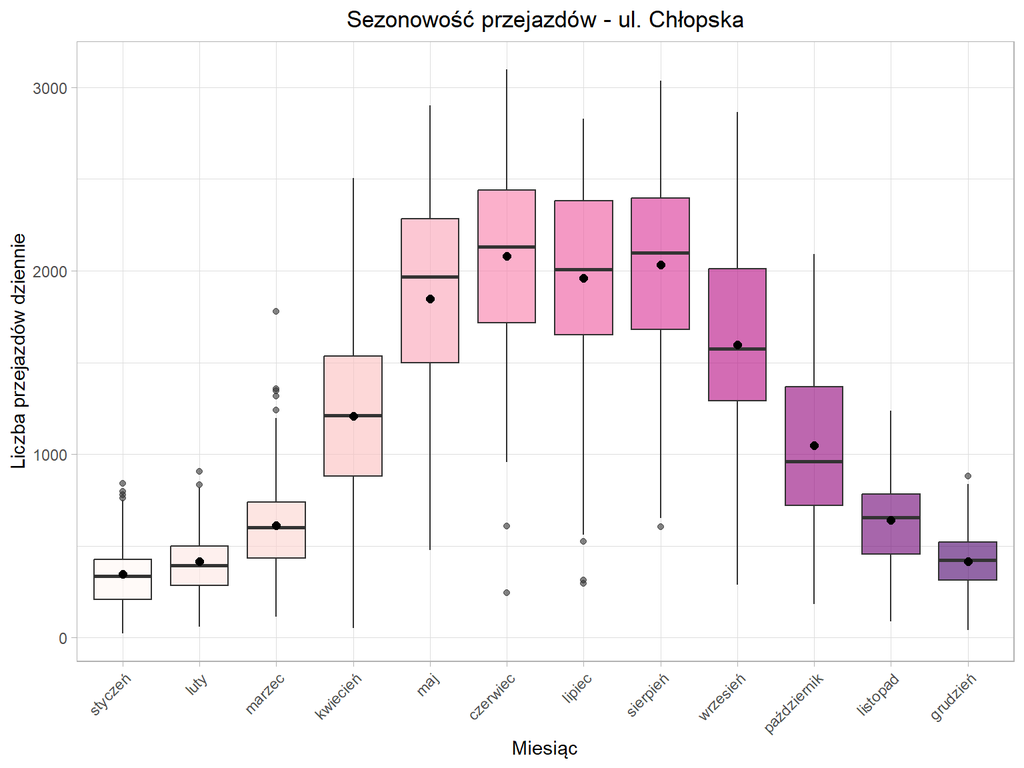

```r
ggplot(dane_stacja, aes(x = Miesiac, y = Licznik, fill = Miesiac)) +
  geom_boxplot(alpha = 0.6, show.legend = FALSE) +
  stat_summary(fun = "mean", geom = "point", color = "black", size = 2, show.legend = FALSE) +
    labs(title = paste("Sezonowość przejazdów -", stacja_wybrana),
       x = "Miesiąc",
       y = "Liczba przejazdów dziennie") +
  theme_light() +
  scale_fill_manual(values = colorRampPalette(paleta_kolorow)(12)) +
  theme(axis.text.x = element_text(angle = 45, hjust = 1),
        plot.title = element_text(hjust = 0.5))
```

## Porównanie stacji pod względem zależności z poprzedniego punktu

Wybrano dwie dodatkowe stacje dla porównania z stacją “Ul. Chłopska”.

```r
wybrane_stacje <- c("ul. Kartuska", "al. Grunwaldzka (UG)", "ul. Chłopska")

dane_porownanie <- przejazdy[przejazdy$Stacja %in% wybrane_stacje, ]

dane_porownanie$Stacja <- factor(dane_porownanie$Stacja, levels = wybrane_stacje) # kolejnosc
```

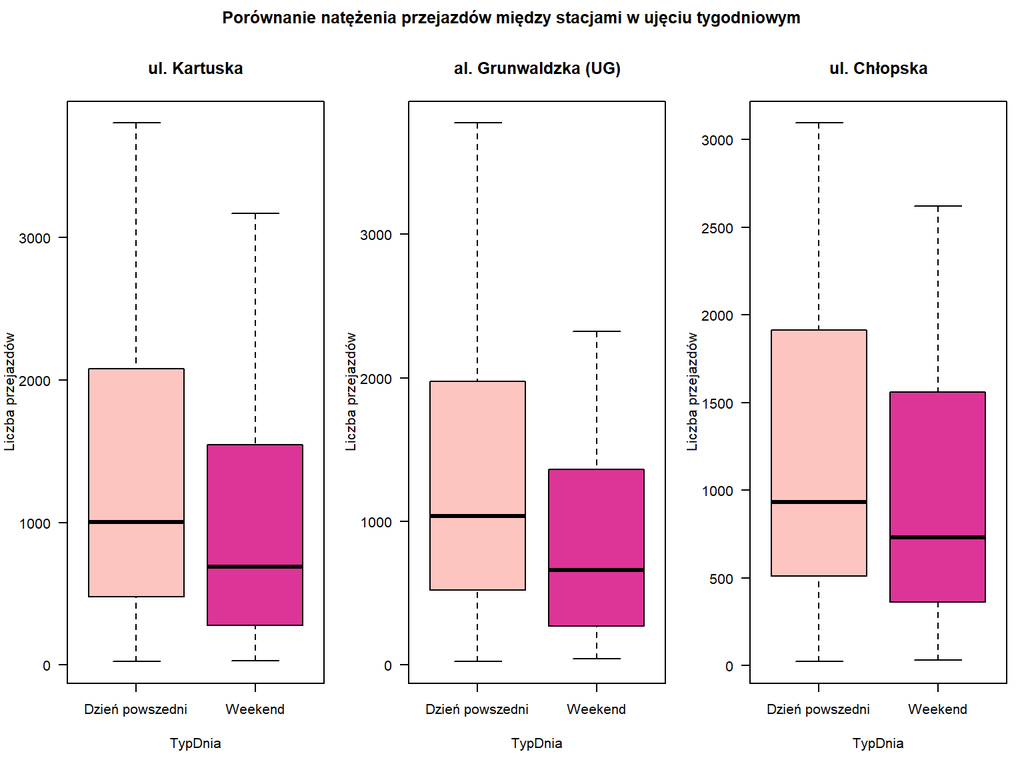

```r
stare_par <- par(mfrow = c(1, 3), mar = c(5, 4, 4, 1), oma = c(0, 0, 2, 0))

for(s in wybrane_stacje) {
  boxplot(Licznik ~ TypDnia,
          data = dane_porownanie[dane_porownanie$Stacja == s, ],
          main = s,
          col = c(paleta_kolorow[3], paleta_kolorow[6]),
          las = 1,
          ylab = "Liczba przejazdów",
          outline = FALSE)
}

title(main = "Porównanie natężenia przejazdów między stacjami w ujęciu tygodniowym", outer = TRUE)
```

```r
par(stare_par)
```

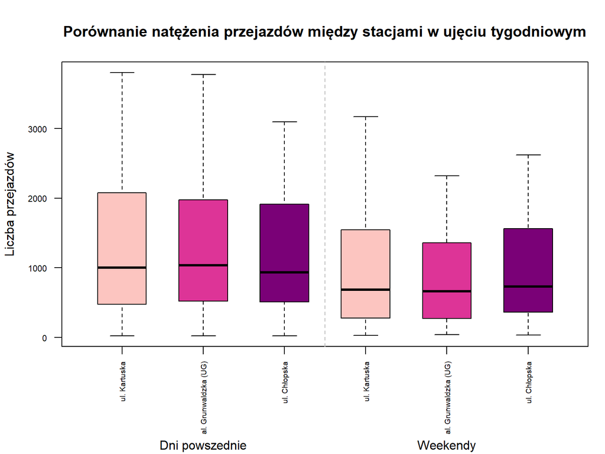

```r
par(mar = c(7, 4, 4, 1) + 0.1)

boxplot(Licznik ~ Stacja * TypDnia,
        data = dane_porownanie,
        boxwex = 0.6,
        col = rep(paleta_kolorow[c(3, 6, 8)], 2),
        main = "Porównanie natężenia przejazdów między stacjami w ujęciu tygodniowym",
        ylab = "Liczba przejazdów",
        xlab = "",
        las = 2,
        cex.axis = 0.7,
        xaxt = "n",
        outline = FALSE)

axis(1, at = 1:6, labels = rep(wybrane_stacje, 2), las = 2, cex.axis = 0.6)

mtext("Dni powszednie", side = 1, line = 6, at = 2)
mtext("Weekendy", side = 1, line = 6, at = 5)

abline(v = 3.5, lty = 2, col = "grey")
```

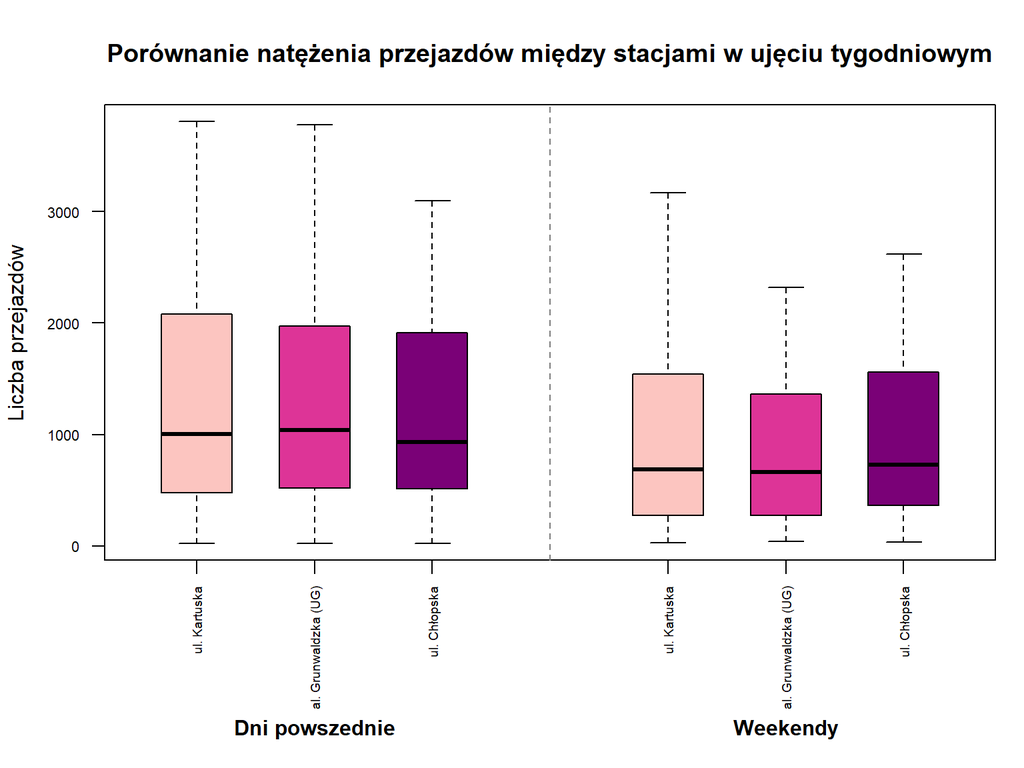

```r
par(mar = c(8, 4, 4, 1) + 0.1)

pozycje <- c(1, 2, 3, 5, 6, 7) # cel: lepiej rozgraniczyć dni powszednie od weekendow

boxplot(Licznik ~ Stacja * TypDnia,
        data = dane_porownanie,
        at = pozycje,
        boxwex = 0.6,
        col = rep(paleta_kolorow[c(3, 6, 8)], 2),
        main = "Porównanie natężenia przejazdów między stacjami w ujęciu tygodniowym",
        ylab = "Liczba przejazdów",
        xlab = "",
        las = 2,
        cex.axis = 0.7,
        xaxt = "n",
        outline = FALSE)

axis(1, at = pozycje, labels = rep(wybrane_stacje, 2), las = 2, cex.axis = 0.6)

mtext("Dni powszednie", side = 1, line = 6, at = 2, font = 2)
mtext("Weekendy", side = 1, line = 6, at = 6, font = 2)

abline(v = 4, lty = 2, col = "grey50")
```

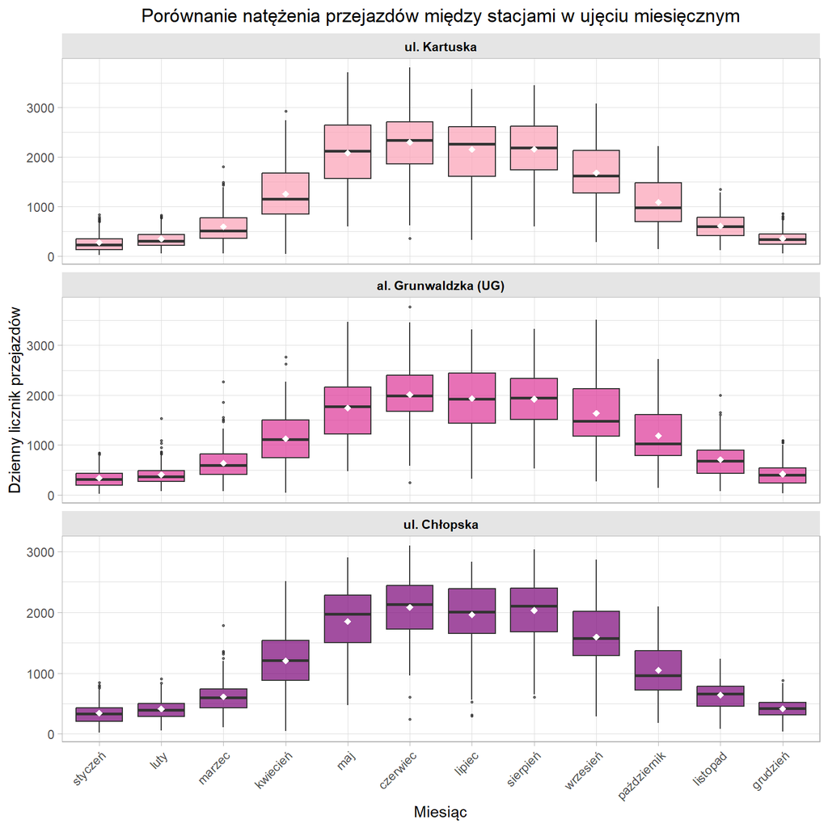

```r
ggplot(dane_porownanie, aes(x = Miesiac, y = Licznik, fill = Stacja)) +
  geom_boxplot(alpha = 0.7, show.legend = FALSE, outlier.size = 0.5) +
  stat_summary(fun = "mean", geom = "point", color = "white",
               shape = 18, size = 2, show.legend = FALSE) +
  facet_wrap(vars(Stacja), ncol = 1, scales = "free_y") +
  scale_fill_manual(values = c(paleta_kolorow[4], paleta_kolorow[6], paleta_kolorow[8])) +
  labs(title = "Porównanie natężenia przejazdów między stacjami w ujęciu miesięcznym",
       x = "Miesiąc",
       y = "Dzienny licznik przejazdów") +
  theme_light() +
  theme(axis.text.x = element_text(angle = 45, hjust = 1),
        strip.background = element_rect(fill = "grey90"),
        strip.text = element_text(color = "black", face = "bold"),
        plot.title = element_text(hjust = 0.5))
```

## Zależność między liczbą przejazdów a wybranymi warunkami pogodowymi dla wybranej stacji

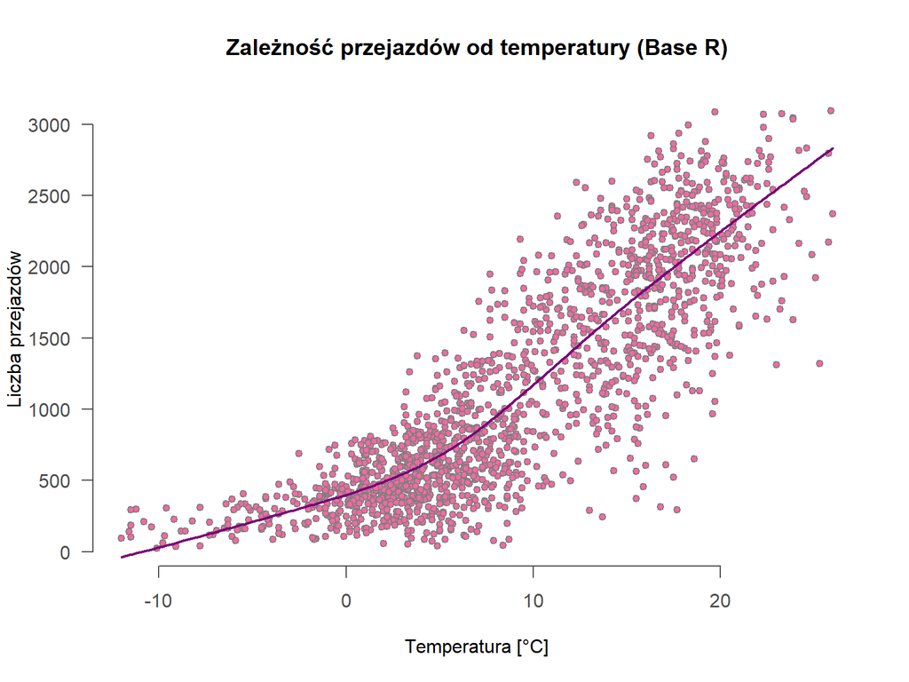

```r
stare_par <- par(bg = "white", col.axis = "grey30", fg = "grey30")

with(dane_stacja, plot(Temperatura, Licznik,
                       main = "Zależność przejazdów od temperatury (Base R)",
                       xlab = "Temperatura [°C]",
                       ylab = "Liczba przejazdów",
                       pch = 21,
                       col = "grey50",
                       bg = paleta_kolorow[5],
                       cex = 0.8,
                       las = 1,
                       bty = "n"))

lines(lowess(dane_stacja$Temperatura, dane_stacja$Licznik),
      col = paleta_kolorow[8], lwd = 2)
```

```r
par(stare_par)
```

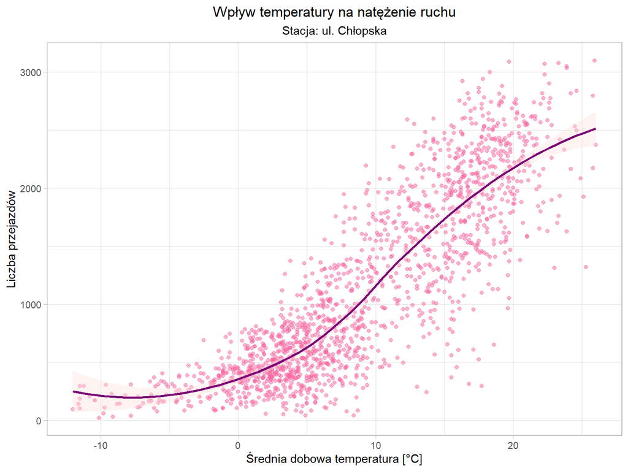

```r
ggplot(dane_stacja, aes(x = Temperatura, y = Licznik)) +
  geom_point(color = paleta_kolorow[5], alpha = 0.5) +
  geom_smooth(method = "loess", color = paleta_kolorow[8], fill = paleta_kolorow[2]) +
  labs(title = "Wpływ temperatury na natężenie ruchu",
       subtitle = "Stacja: ul. Chłopska",
       x = "Średnia dobowa temperatura [°C]",
       y = "Liczba przejazdów") +
  theme_light() +
  theme(plot.title = element_text(hjust = 0.5),
        plot.subtitle = element_text(hjust = 0.5))
```

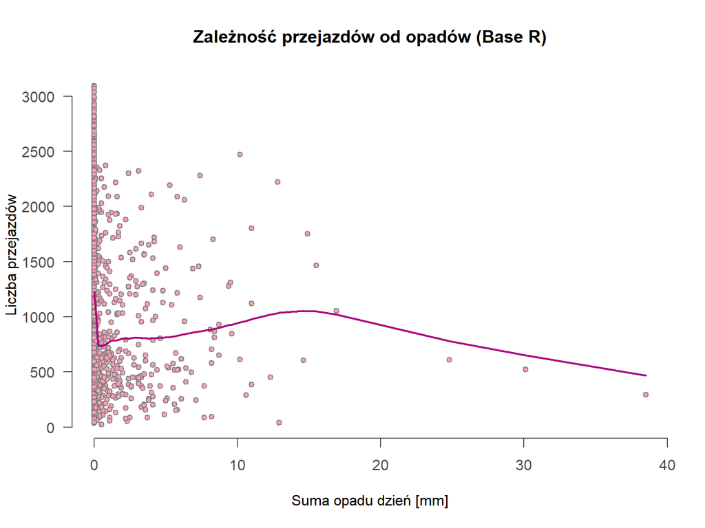

```r
stare_par <- par(bg = "white", col.axis = "grey30", fg = "grey30")

with(dane_stacja, plot(Opady_dzień, Licznik,
                       main = "Zależność przejazdów od opadów (Base R)",
                       xlab = "Suma opadu dzień [mm]",
                       ylab = "Liczba przejazdów",
                       pch = 21,
                       col = "grey50",
                       bg = paleta_kolorow[4],
                       cex = 0.8,
                       las = 1,
                       bty = "n"))

lines(lowess(dane_stacja$Opady_dzień, dane_stacja$Licznik),
      col = paleta_kolorow[7], lwd = 2)
```